# Flight Schedule Pro - Technical Assessment

## Introduction

For my assessment, I thought it best to do some exploratory data analysis to showcase due dilligence in understanding a completely new data domain for me. In practice I would work with more subject matter experts within the team to get a sense for the business context and value of this data before diving straight in. I will break down my approach with markdown cells in between the analysis and explain my work as I go.

There are two ultimate goals I will be pursuing:

1. Data Exploration and Cleansing
   - Being critical and skeptical about the data is important in understanding data quality
   - Skills in navigating set-based operations, SQL-like transformations in memory, and basic governance
2. Visualizing the data for various insights
   - Identify metrics that may be of interest to explore given so many are available in the dataset
   - Showing capabilities with data visualization, basic analysis, basic stats, etc.
   - Hypothesis generation with a brand new data domain

## Data Exploration and Cleansing

My first step will be loading some specific packages to ingest the csv file, and do some preliminary work to understand the data structure.

```python
import pandas as pd

df = pd.read_csv('./data/Consumer_Airfare_Report__Table_7_-_Fare_Premiums_for_Select_Cities_with_More_Than_20_Passengers_per_Day.csv')
df.head()
```

|  | tbl | Year | quarter | citymarketid | cityname | airportid | apt | TotalMkts | TotalFaredPax | TotalPerLFMkts | ... | SHPax | SHPerLFMkts | SHAvgHubFare | SHPerPrem | LHMkts | LHPax | LHPerLFMkts | LHAvgHubFare | LHPerPrem | tbl7pk |
| --- | --- | --- | --- | --- | --- | --- | --- | --- | --- | --- | --- | --- | --- | --- | --- | --- | --- | --- | --- | --- | --- |
| 0 | Table 7 | 2022 | 3 | 30140 | Albuquerque, NM | 10140 | ABQ | 85 | 893800 | 0.9520 | ... | 378030.0 | 0.9394 | 193.75 | -0.0214 | 66.0 | 515770.0 | 0.9612 | 300.08 | 0.0448 | 2022310140ABQ |
| 1 | Table 7 | 2022 | 3 | 30154 | Nantucket, MA | 10154 | ACK | 20 | 110630 | 0.8892 | ... | 95160.0 | 0.8717 | 187.71 | 0.4902 | 11.0 | 15470.0 | 0.9968 | 471.45 | 0.3337 | 2022310154ACK |
| 2 | Table 7 | 2022 | 3 | 30157 | Eureka/Arcata, CA | 10157 | ACV | 7 | 27540 | 0.3468 | ... | 24560.0 | 0.3888 | 183.11 | -0.1167 | 1.0 | 2980.0 | 0.0000 | 310.77 | 0.2279 | 2022310157ACV |
| 3 | Table 7 | 2022 | 3 | 30208 | Augusta, GA | 10208 | AGS | 33 | 55610 | 0.0000 | ... | 32170.0 | 0.0000 | 271.82 | 0.0772 | 18.0 | 23440.0 | 0.0000 | 382.43 | 0.1404 | 2022310208AGS |
| 4 | Table 7 | 2022 | 3 | 30257 | Albany, NY | 10257 | ALB | 71 | 547460 | 0.8805 | ... | 169900.0 | 0.6150 | 218.53 | 0.0402 | 45.0 | 377560.0 | 1.0000 | 290.05 | 0.0017 | 2022310257ALB |

5 rows × 23 columns

I like to first understand the granularity of the data. It appears that our data grain is at a specific year, quarter, and airport id. The `tbl17pk` column is a primary key, so let's check if it's truly unique for each row, since it appears to be a string concatenation of just the `Year`, `quarter`, `airportid` and `apt`.

```python
print(f"No. of Rows: {df.shape[0]}")
print(f"No. of Columns: {df.shape[1]}")
```

```
No. of Rows: 22619
No. of Columns: 23
```

```python
# Check that the PK is truly unique for each row, and we don't have other granularity
len(df.tbl7pk.unique()) == df.shape[0]
```

```
True
```

```python
years = df.Year.unique()
years.sort()

years
```

```
array([1996, 1997, 1998, 1999, 2000, 2001, 2002, 2003, 2004, 2005, 2006,
       2007, 2008, 2009, 2010, 2011, 2012, 2013, 2014, 2015, 2016, 2017,
       2018, 2019, 2020, 2021, 2022, 2023, 2024])
```

```python
len(years)
```

```
29
```

I also want to understand if years are complete, and noticed that some years have less records, so we have to be careful when assessing trends that may have gaps between the years.

First, we notice that 2024 is not a complete year, so we want to exclude that for year-over-year trend analysis.

```python
df_2024 = df[df.Year == 2024]
df_2024[['Year','quarter']].drop_duplicates().style.hide(axis='index')
```

| Year | quarter |
| --- | --- |
| 2024 | 1 |
| 2024 | 2 |
| 2024 | 3 |

Next we notice that the year 2020 is an exception for a single airport, so we also need to be careful in analyzing trends when there are gaps in the data. Notice that Q2 and Q4 are missing from Nashville's 2020 data. With more time I'd try to analyze if this gap was across all airports, since 2020 was certainly an odd year for airport travel given COVID implications.

```python
bna_2020_example = df[(df.Year == 2020) & (df.apt == 'BNA')]
bna_2020_example[['Year','quarter']].drop_duplicates().style.hide(axis='index')
```

| Year | quarter |
| --- | --- |
| 2020 | 3 |
| 2020 | 1 |

Prior to this step, I read the [data dictionary](https://data.transportation.gov/Aviation/Consumer-Airfare-Report-Table-7-Fare-Premiums-for-/d6nc-s8v6/about_data) to understand what columns were available.

One curiosity I had was

> How many distinct airports can be in a `citymarketid`?

```python
unique_airports_df = (
    df.groupby(['Year', 'quarter', 'citymarketid'])['airportid']
    .nunique()
    .reset_index(name='distinct_airport_count')
)
```

```python
(unique_airports_df['distinct_airport_count'].value_counts()
     .to_frame()
     .sort_values(by='distinct_airport_count', ascending=False)
)
```

| distinct_airport_count | count |
| --- | --- |
| 7 | 26 |
| 6 | 83 |
| 5 | 117 |
| 4 | 24 |
| 3 | 377 |
| 2 | 933 |
| 1 | 18261 |

The above summary table shows me that most `citymarketid`'s have only one airport or two airports, with a long tail out to a max of 7 airports per citymarket. I find that an interesting fact to simply understand the relationship between a city and an airport, and the overall cardinality of potential shared airports within a market.

### Basic Transformations for visualization/analysis

I wanted to add a combined `year_qt` field that is a concatenation of the year and quarter. It will look better in trend visualizations and allow me to use a single field for that array sorting if needed.

I will also reset the index after sorting so that by default the dataframe and any copies will have this inherent sort pattern.

```python
# adding year-quarter single column
df['year_qt'] =  df['Year'].astype(str) + '-Q' + df['quarter'].astype(str)
df.sort_values(by=['Year', 'quarter'], inplace=True)
df.reset_index(drop=True)
```

|  | tbl | Year | quarter | citymarketid | cityname | airportid | apt | TotalMkts | TotalFaredPax | TotalPerLFMkts | ... | SHPerLFMkts | SHAvgHubFare | SHPerPrem | LHMkts | LHPax | LHPerLFMkts | LHAvgHubFare | LHPerPrem | tbl7pk | year_qt |
| --- | --- | --- | --- | --- | --- | --- | --- | --- | --- | --- | --- | --- | --- | --- | --- | --- | --- | --- | --- | --- | --- |
| 0 | Table 7 | 1996 | 1 | 32397 | Ithaca/Cortland, NY | 12397 | ITH | 9 | 7990 | 0.0000 | ... | 0.0000 | 175.08 | 0.2080 | 6.0 | 5940.0 | 0.0000 | 200.58 | -0.1219 | 1996112397ITH | 1996-Q1 |
| 1 | Table 7 | 1996 | 1 | 33367 | Quad Cities, IL (Metropolitan Area) | 13367 | MLI | 32 | 55190 | 0.0000 | ... | 0.0000 | 194.32 | 0.2815 | 22.0 | 31560.0 | 0.0000 | 197.57 | 0.0069 | 1996113367MLI | 1996-Q1 |
| 2 | Table 7 | 1996 | 1 | 31504 | Valparaiso, FL | 15624 | VPS | 21 | 25060 | 0.0000 | ... | 0.0000 | 226.10 | 0.1634 | 18.0 | 18170.0 | 0.0000 | 233.81 | 0.2307 | 1996115624VPS | 1996-Q1 |
| 3 | Table 7 | 1996 | 1 | 34653 | Tulsa, OK | 15370 | TUL | 68 | 466860 | 0.6174 | ... | 0.5950 | 109.71 | -0.2468 | 40.0 | 164580.0 | 0.6585 | 187.25 | -0.0515 | 1996115370TUL | 1996-Q1 |
| 4 | Table 7 | 1996 | 1 | 35323 | Bristol/Johnson City/Kingsport, TN | 15323 | TRI | 16 | 21380 | 0.0000 | ... | 0.0000 | 195.52 | -0.0271 | 1.0 | 2020.0 | 0.0000 | 261.55 | 0.3762 | 1996115323TRI | 1996-Q1 |
| ... | ... | ... | ... | ... | ... | ... | ... | ... | ... | ... | ... | ... | ... | ... | ... | ... | ... | ... | ... | ... | ... |
| 22614 | Table 7 | 2024 | 3 | 31252 | Daytona Beach, FL | 11252 | DAB | 31 | 73350 | 0.1303 | ... | 0.0000 | 247.00 | 0.1956 | 24.0 | 47520.0 | 0.2012 | 241.98 | -0.0451 | 2024311252DAB | 2024-Q3 |
| 22615 | Table 7 | 2024 | 3 | 31638 | Fresno, CA | 11638 | FAT | 67 | 402270 | 0.6514 | ... | 0.4697 | 207.49 | 0.0353 | 53.0 | 238220.0 | 0.7765 | 315.62 | -0.0139 | 2024311638FAT | 2024-Q3 |
| 22616 | Table 7 | 2024 | 3 | 30627 | Bismarck/Mandan, ND | 10627 | BIS | 28 | 67100 | 0.2768 | ... | 0.0000 | 269.54 | 0.4665 | 24.0 | 49470.0 | 0.3754 | 249.86 | -0.1174 | 2024310627BIS | 2024-Q3 |
| 22617 | Table 7 | 2024 | 3 | 32945 | Lexington, KY | 12945 | LEX | 57 | 227350 | 0.1814 | ... | 0.1705 | 231.96 | 0.0513 | 28.0 | 103270.0 | 0.1944 | 293.02 | 0.0272 | 2024312945LEX | 2024-Q3 |
| 22618 | Table 7 | 2024 | 3 | 34570 | Reno, NV | 14570 | RNO | 80 | 920070 | 0.8991 | ... | 0.8644 | 193.82 | -0.0066 | 61.0 | 447500.0 | 0.9358 | 311.49 | 0.0218 | 2024314570RNO | 2024-Q3 |

22619 rows × 24 columns

## Visualizing the data for various insights

### Exploring naive hypotheses about the data

Without a lot of domaim expertise to know what is most applicable to Flight Schedule Pro, I simply did a few explorations to see what relationships seemed interesting to me.

I will often slice this down to a single year and quarter pair, and with more time, I would see if there were shifts over time.

Here are a few of those ideas:

- Relationship between TotalAvgHubFare (Market average fare in all markets) vs. Total Mkts
  - **Hypothesis:** Service more markets would command a higher average hub fair
- Short Hall vs. Long Haul Markets - ratio of this (assuming this means how many markets they serve that are short distance vs. long distance?)
- Random interesting patterns that I could find with a quick visual search

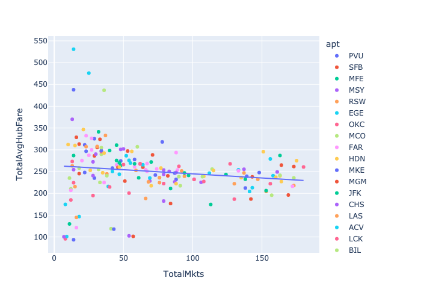

```python
import plotly.express as px
import plotly
import plotly.io as pio
pio.renderers.keys()

pio.renderers.default = 'png'

# Using 2023 as the latest year with all 4 quarters as the basis for analysis
df_2023 = df[df.Year == 2023].copy()
df_2023.reset_index(inplace=True)
df_2023_q4 = df_2023[df_2023.quarter == 4].copy()
df_2023_q4.reset_index(inplace=True)

fig = px.scatter(df_2023_q4,
                 x='TotalMkts',
                 y='TotalAvgHubFare',
                 hover_name='apt',
                 color='apt',
                 trendline='ols',
                 trendline_scope='overall',
)

fig.show()
```

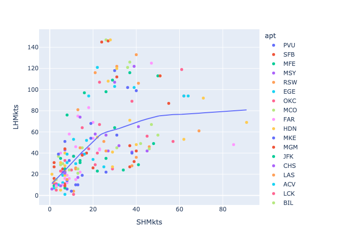

```python
fig = px.scatter(df_2023[df_2023.quarter == 4],
                 x='SHMkts',
                 y='LHMkts',
                 hover_name='apt',
                 color='apt',
                 trendline='lowess',
                 trendline_scope='overall',
)

fig.show()
```

Interesting that there is a positive relationship between the number of short haul markets and long haul markets. Although the relationship does not appear to be linear, and after a certain point, adding more short haul markets doesn't necessarily mean more long haul markets are added (perhaps becaus there is a ceiling/limited number of long haul markets in general).

### Visual exploration of interesting relationships

For this next section, I wanted to visualize pairs of other metrics to see any intersting relationships that exist. I use plotly's `scatter_matrix` to show multiple relationships at a time.

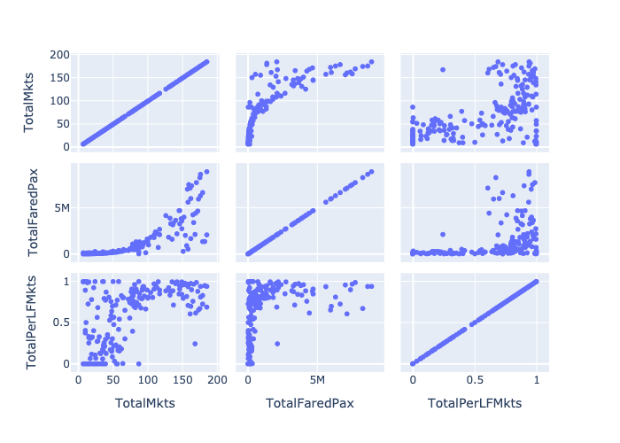

```python
scatter_matrix = px.scatter_matrix(
    df[df['year_qt'] == '2024-Q3'],
    dimensions=['TotalMkts','TotalFaredPax', 'TotalPerLFMkts']
)
scatter_matrix.show()
```

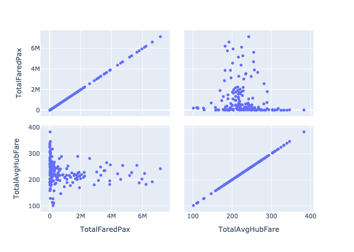

```python
scatter_matrix = px.scatter_matrix(
    df[df['year_qt'] == '2012-Q2'],
    dimensions=['TotalFaredPax','TotalAvgHubFare']
)
scatter_matrix.show()
```

**Interesting Observations:**

- I thought that there might be a relationship between how expensive the average hub fare was and the total fared passenger amount. It looks like that there is some equilibrium point here, and that there is some in-elastic demand for the higher fare locations.

### Interactive dashboard to explore specific airports

I am a huge proponent of interactive data visualization because I believe it can lead you to data-driven insights faster while also remaining more intuitive to a user.

Here I build a Dash app that can be used to select certain points in the relationship and filter down the datatable below based on what is selected. This is a great repeatable pattern that enables faster iteration of ideas, and in the limited time I just made this very simple. With more time I would polish this to have other inputs/selectors, etc. (as well as take it out of jupyter lab).

```python
import dash
from dash import dcc, html, dash_table
from dash.dependencies import Input, Output
import plotly.express as px
import pandas as pd

# Filter DataFrame
data_df = df[df['year_qt'] == '2024-Q3'].copy()

app = dash.Dash(__name__)

# Layout
app.layout = html.Div([
    dcc.Graph(
        id='scatter-plot',
        figure=px.scatter(
            data_df, x='TotalAvgHubFare', y='TotalFaredPax', custom_data=['tbl7pk']
        ),
        config={'editable': False}
    ),
    dash_table.DataTable(
        id='data-table',
        columns=[{"name": i, "id": i} for i in data_df.columns],
        data=data_df.to_dict('records'),
        row_selectable="multi"
    ),
    html.Div(id='selected-data')
])

# This will update the table based on the data selected from the callback
# It's extra helpful that we have the primary key available.
@app.callback(
    Output('data-table', 'data'),
    Input('scatter-plot', 'selectedData')
)
def update_table(selectedData):
    if selectedData and 'points' in selectedData:
        selected_labels = [point['customdata'][0] for point in selectedData['points']]
        filtered_df = data_df[data_df['tbl7pk'].isin(selected_labels)]
        return filtered_df.to_dict('records')
    else:
        return data_df.to_dict('records')

app.run()
```

[interactive chart not shown]

Here's a video to showcase how it is when it runs:

[figure not shown]

### Seasonality Decomposition

With the remaining time, I thought it would be interesting to see if there was an overall seasonality trent present quarter over quarter across a few years. For this I defined a repeatable function that would allow you to plot the multiple time series decompositions.

```python
import pandas as pd
import numpy as np
from statsmodels.tsa.seasonal import seasonal_decompose, STL , MSTL
import plotly.graph_objects as go
from plotly.subplots import make_subplots

def plot_components(result):

  df = pd.concat([result.observed, result.trend, result.seasonal, result.resid], axis=1)
  df = df.rename(columns={0:'Original Data', 'season':'Seasonal','observed':'Original Data'})
  components = df.columns
  rows = len(components)
  fig = make_subplots(rows=rows, cols=1, shared_xaxes=True, subplot_titles = [i for i in components])

# Plot original data
  for i, col in enumerate(components):
    fig.add_trace(go.Scatter(x=df.index, y=df[col], mode='lines', name=col), row=i+1, col=1)


  # Update layout
  fig.update_layout(
      title='Time Series Decomposition',
      xaxis_title='Time',
      height=1200,
      width=800
  )

  fig.show()
```

After this, I utilize the function after modeling this after a particular set of complete cycle of 3 years (requires Q1-Q4 for all years), for a single airport.

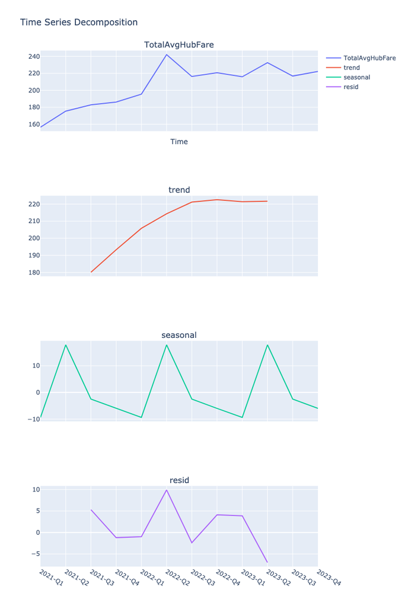

```python
seasonal_df = df[(df['apt'] == 'BNA') &
                 (df['Year'] >= 2021) &
                 (df['Year'] <= 2023)]
seasonal_df.set_index('year_qt', inplace=True)

seasonal_decomp = seasonal_decompose(seasonal_df['TotalAvgHubFare'], model='additive', period=4)
stl = STL(seasonal_df['TotalAvgHubFare'], period=4)
stl_decomp = stl.fit()


plot_components(seasonal_decomp)
```

Here is looks like there is an upward trend of an increase in Total Average Hub Fare, even when taking out seasonality. I would like to give more time to this and analyze more data points to see if this trend holds across more data, but dues to time constraints, I'll leave it at that for now.

## Conclusion

Thank you for taking the time to review my submission and analysis here. I am happy to walk through this and my thought process behind everything. Please reach out with any questions, and thank you again for your time and consideration.